# Project 2 - Internet of Things

## Reading descriptions

We will analyse the variable Opis which is a flag whether a student read description of a unit or not and determine whether there is a relation between this fact and the average duration as well as grades.

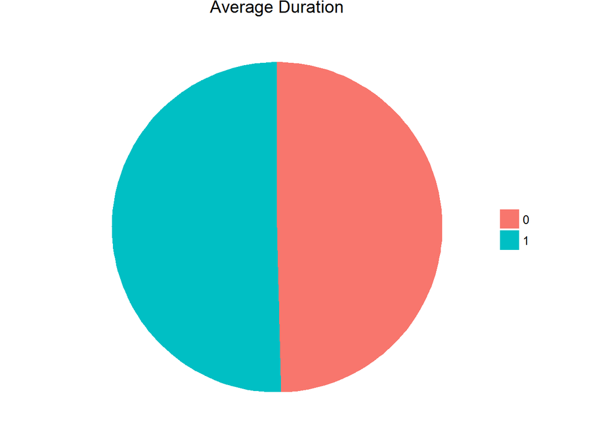

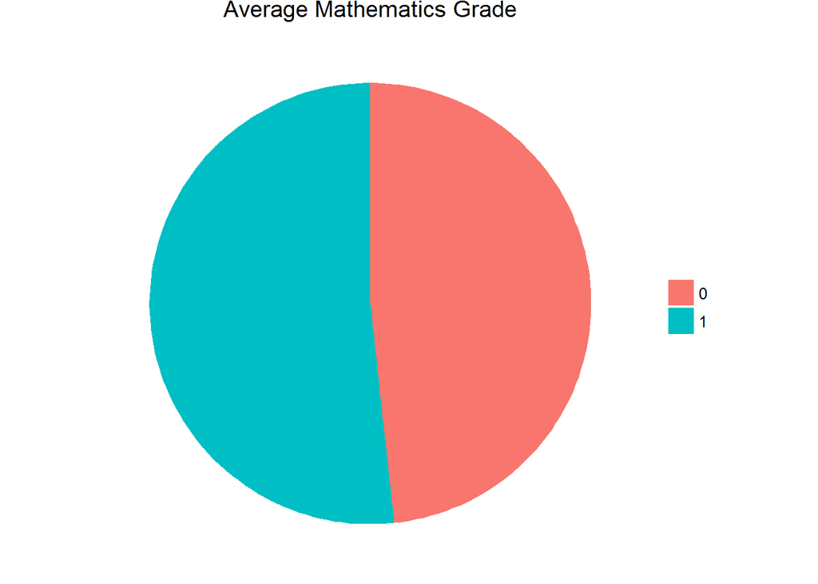

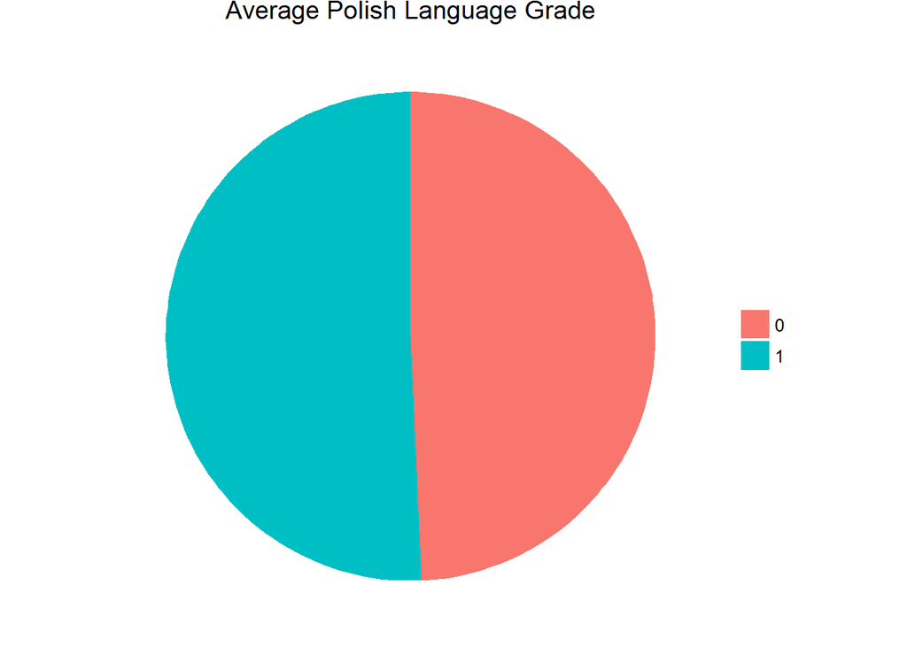

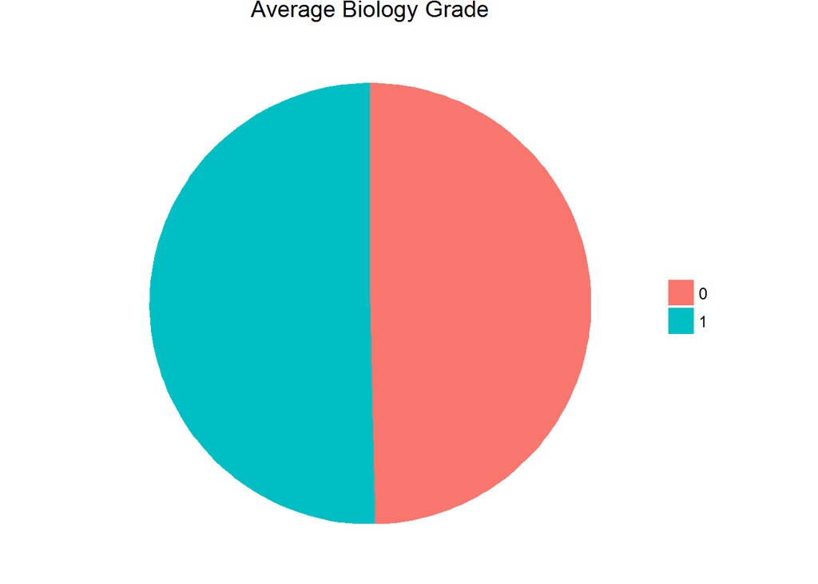

The difference is only slight, but we can see that students that read descriptions spend a little more time interacting with units and have on average higher grades. This can be the best observed when looking at the average proposed grades from Mathematics.

## Aspirations

We thought it would be interesting to check how the average duration and grades look like depending on the aspirations of students (their dream future carreer paths). Because there were a lot of distinct jobs in the data we take into account the 15 most frequently occuring ones.

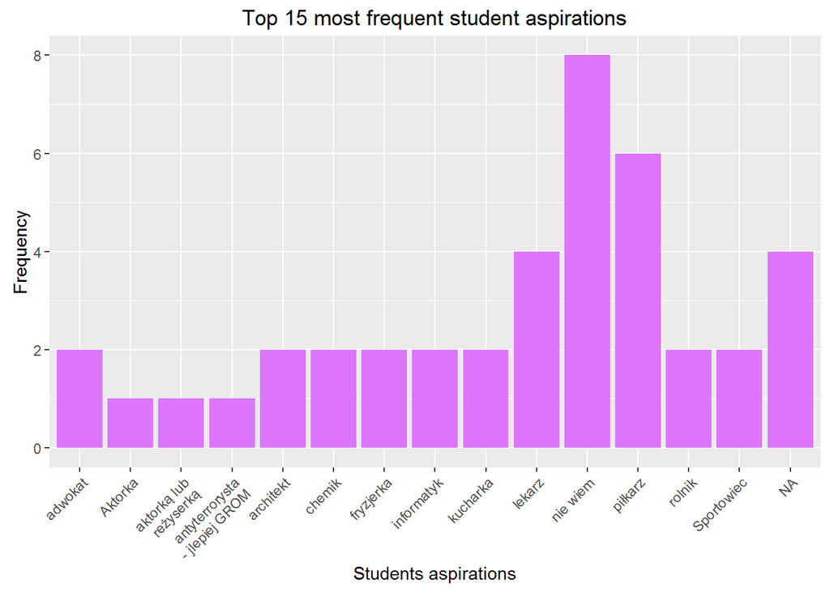

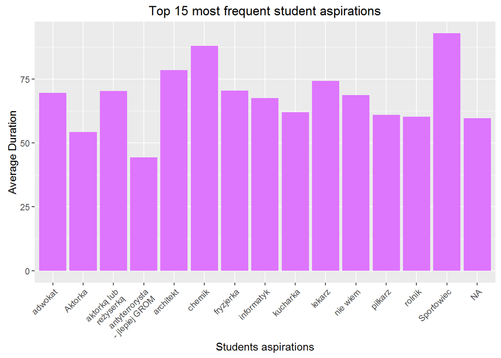

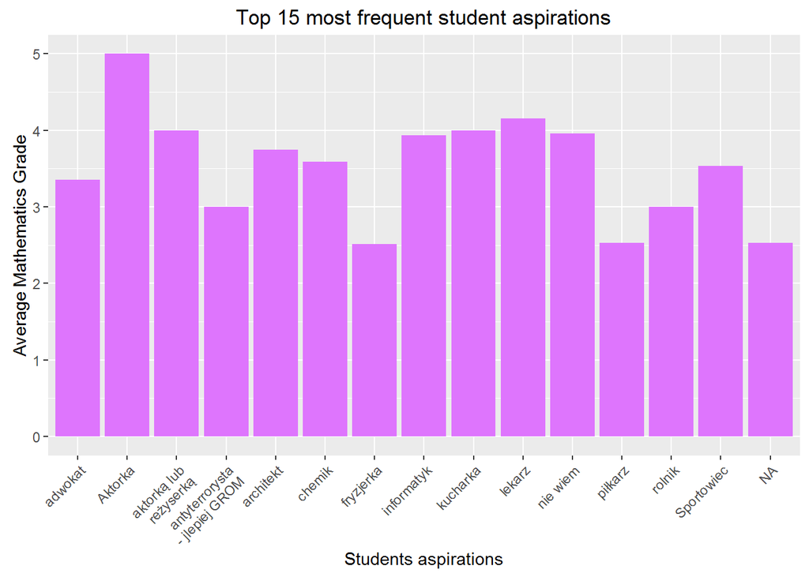

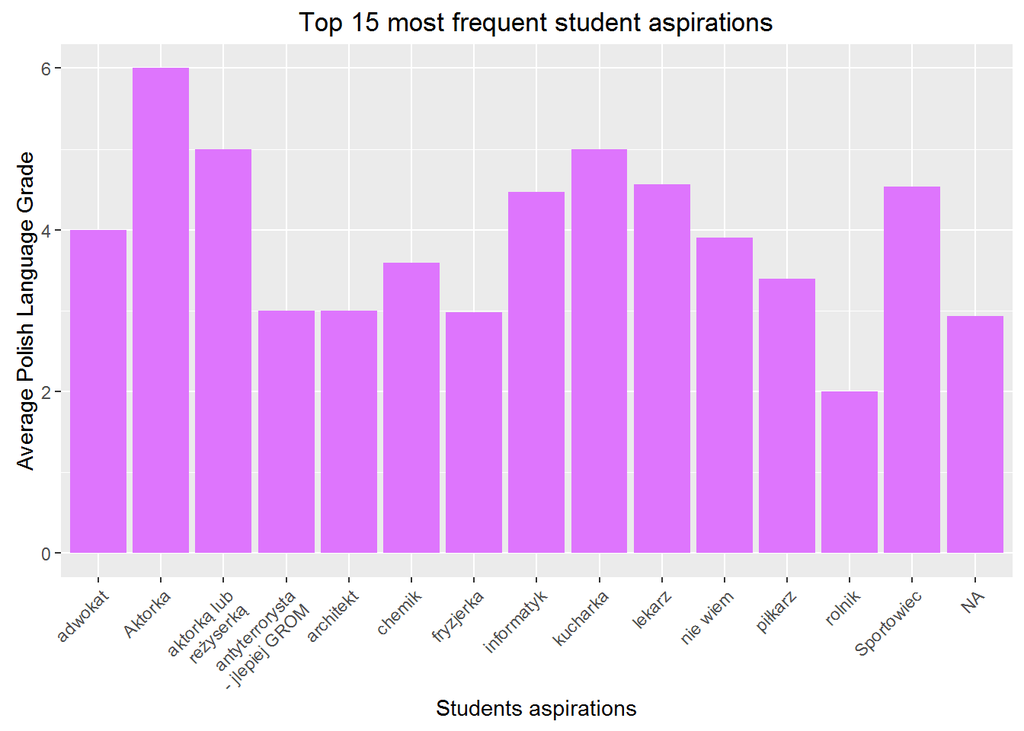

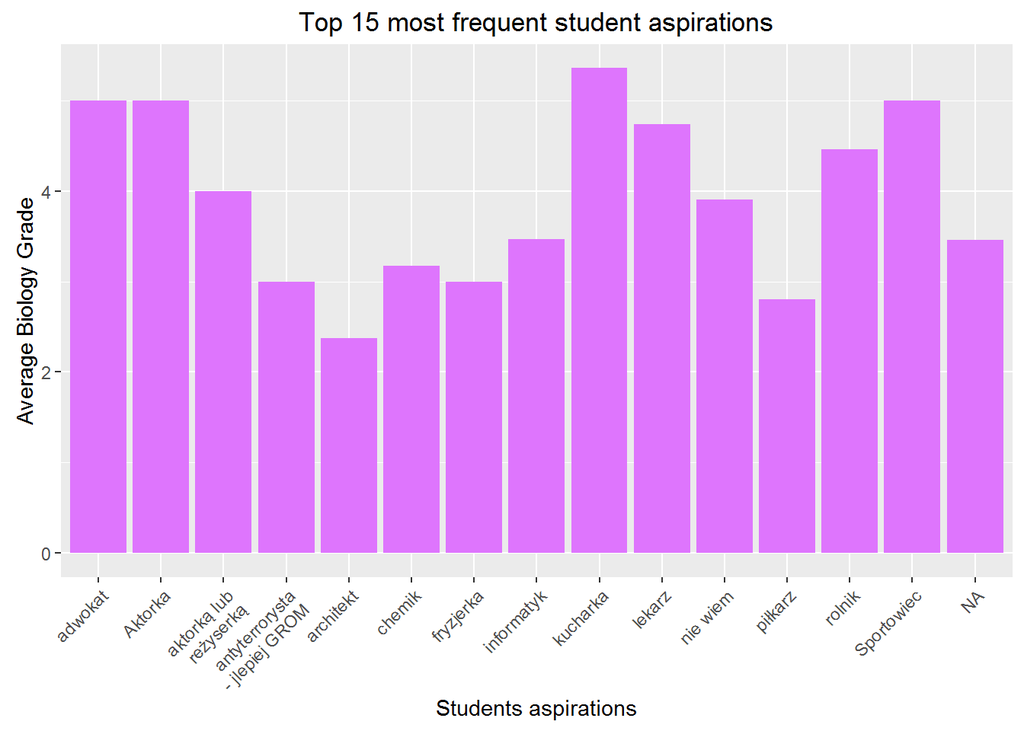

Most of students don’t have their dream job specified, but in terms of other ones soccer player and doctor are the most popular choices with 6 and 4 pupils picking them, respectively.

Future sportmen and chemists interact with units the longest. Actresses however have the highest proposed grades from both Mathematics and Polish language courses. Cooks score the best in Biology.

The subjects and the dream jobs don’t seem to overlap in terms of the area of knowledge which probably is the result of the children still being too young.

# Parents Analysis

Another interesting aspect of analysis is finding correlations between the parents’ occupation, work status or whether they studied with how their children perform.

The analysis will be split for mothers and fathers.

## Work status

Works status answers the question whether a parent currently has a job.

### Mother

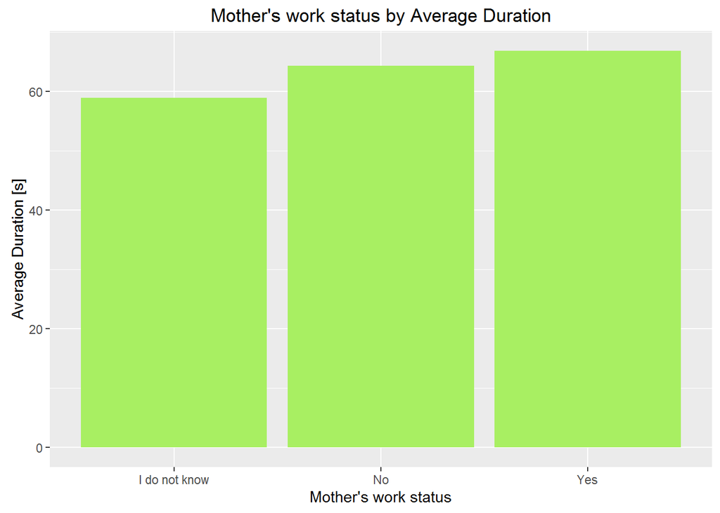

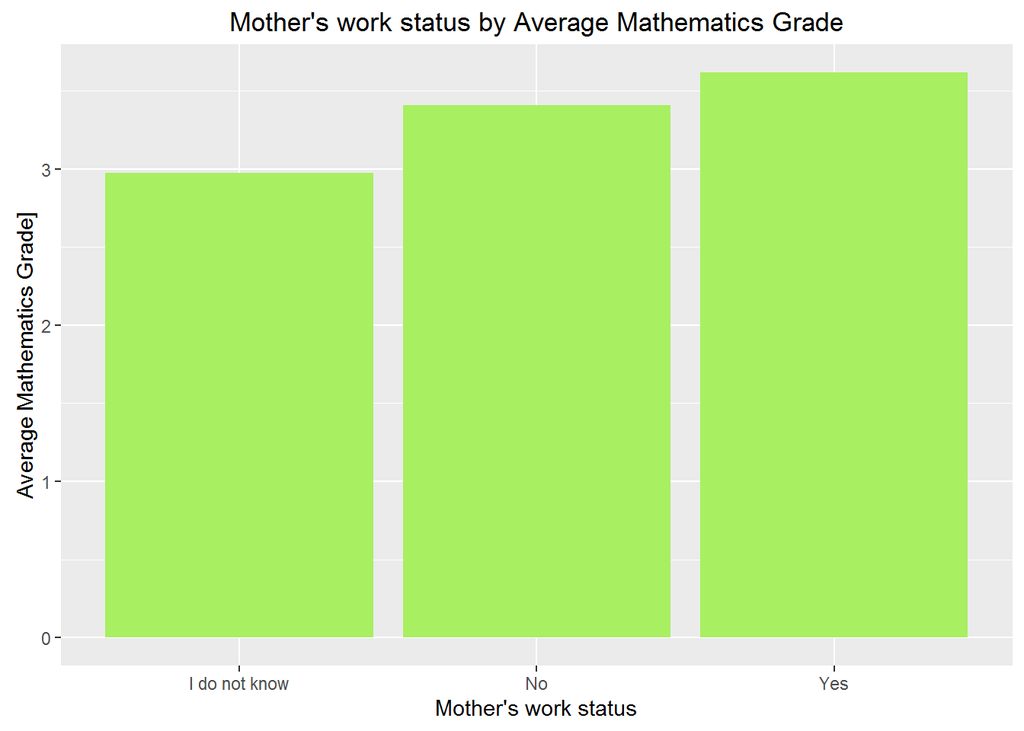

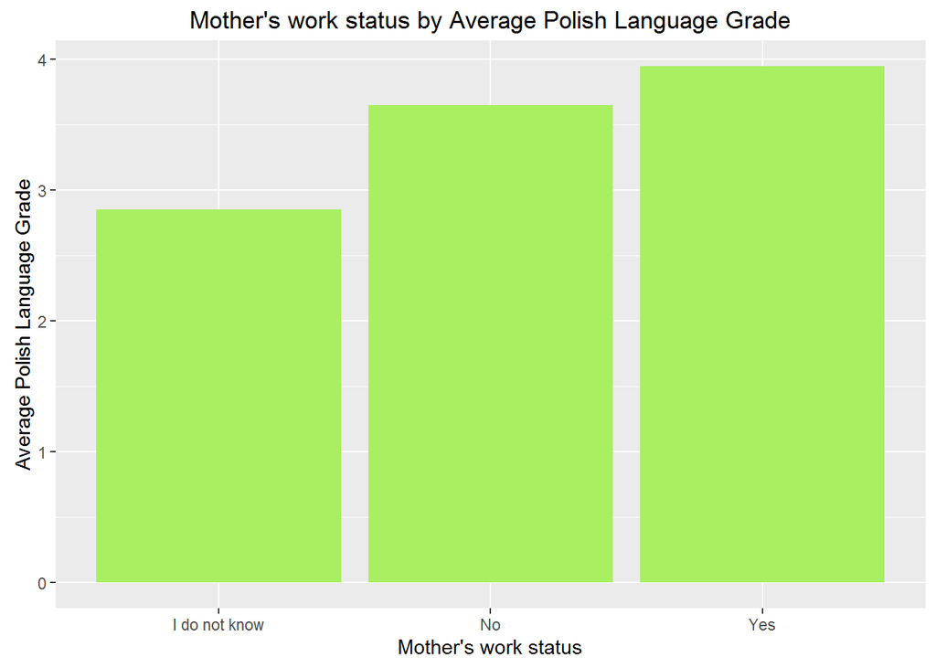

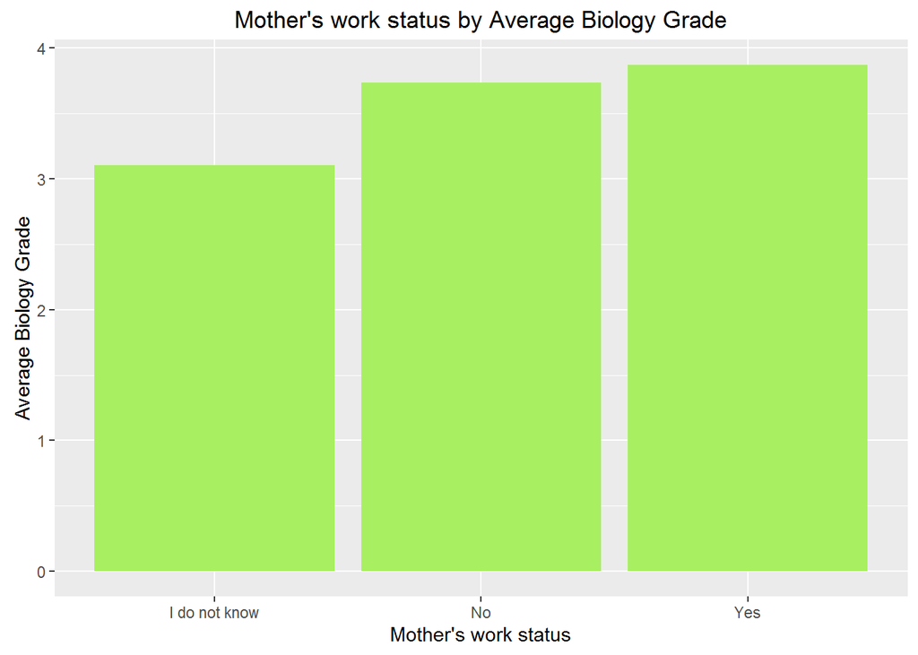

In all the cases the pupils that performed the best at school on average also have a working mother. They also took the longest time interacting with exhibits. Children who do not know their parents status seem to have the worst average grade.

This may lead to a conclusion that a working mother is a good influence on a child.

### Father

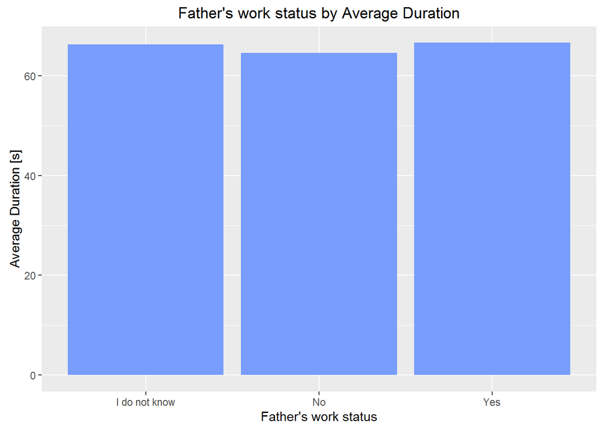

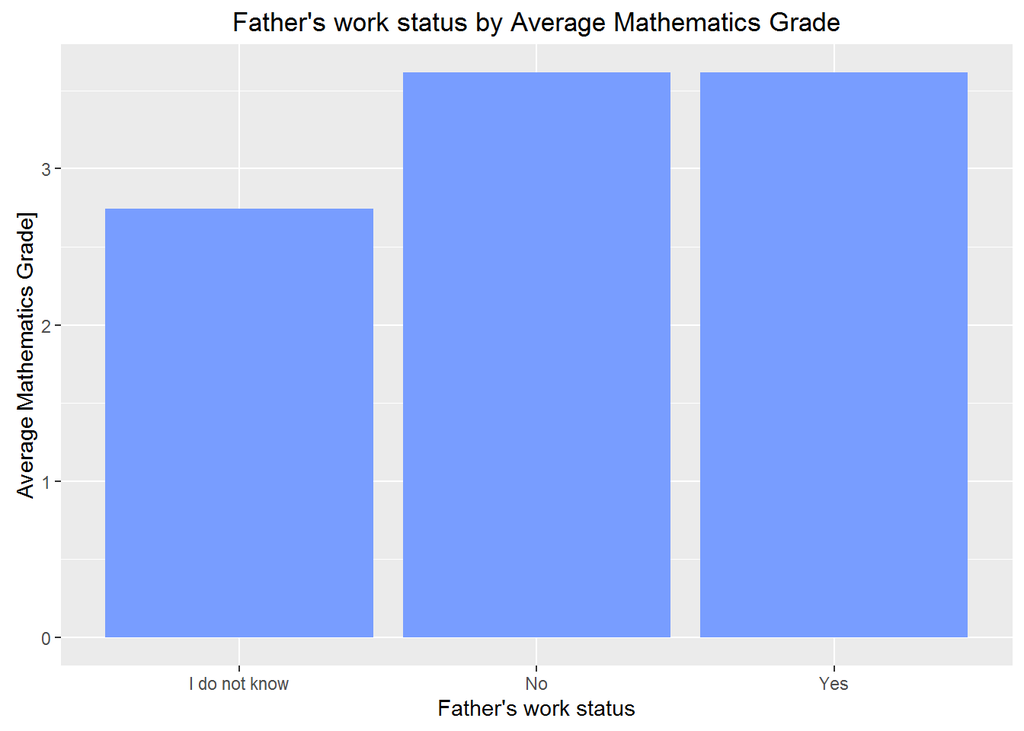

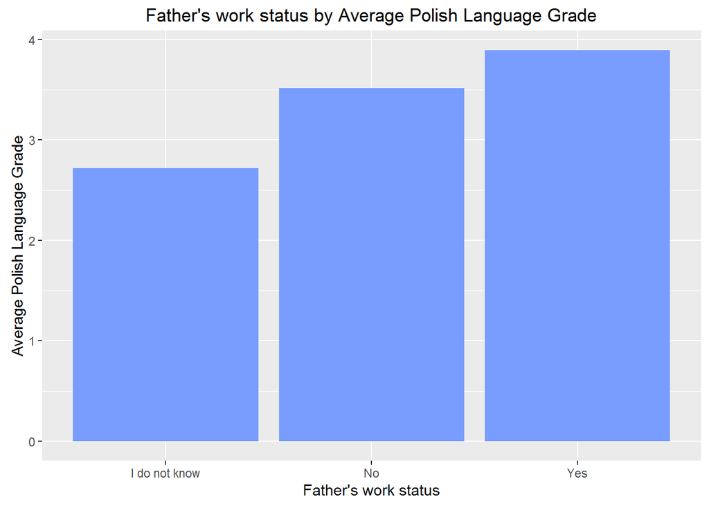

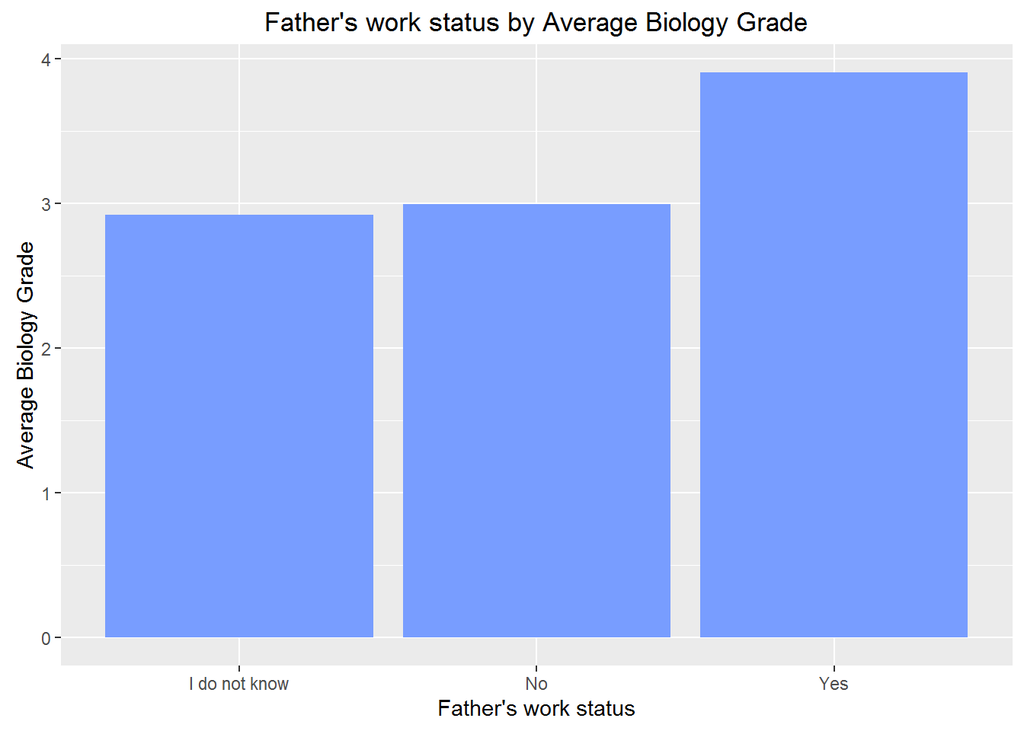

## Occupation

We will try to find out if a parent’s job has an effect on the child. Since there were many occupations in the data, again only the 15 most frequent ones will be analysed.

### Mother

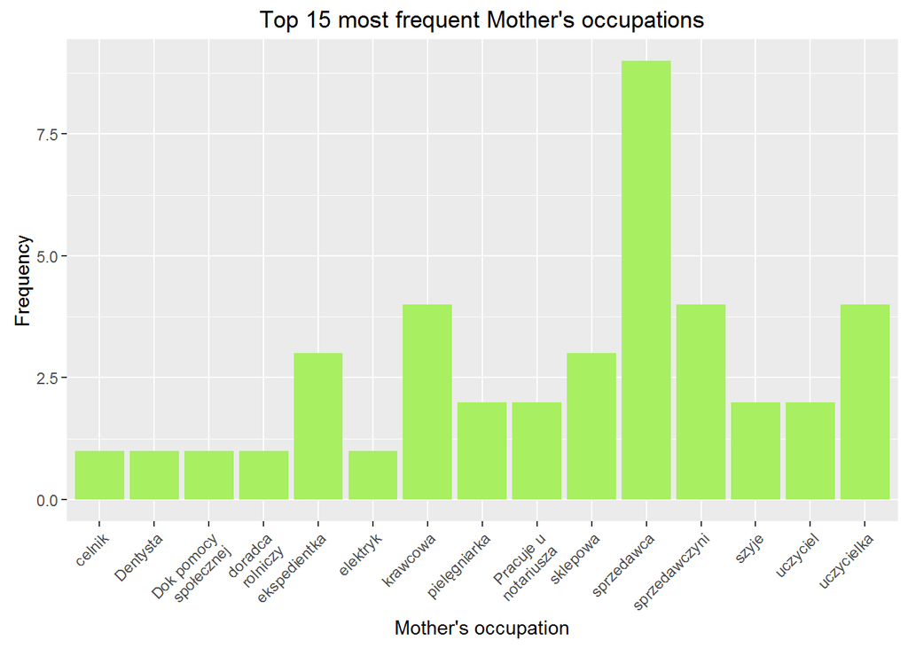

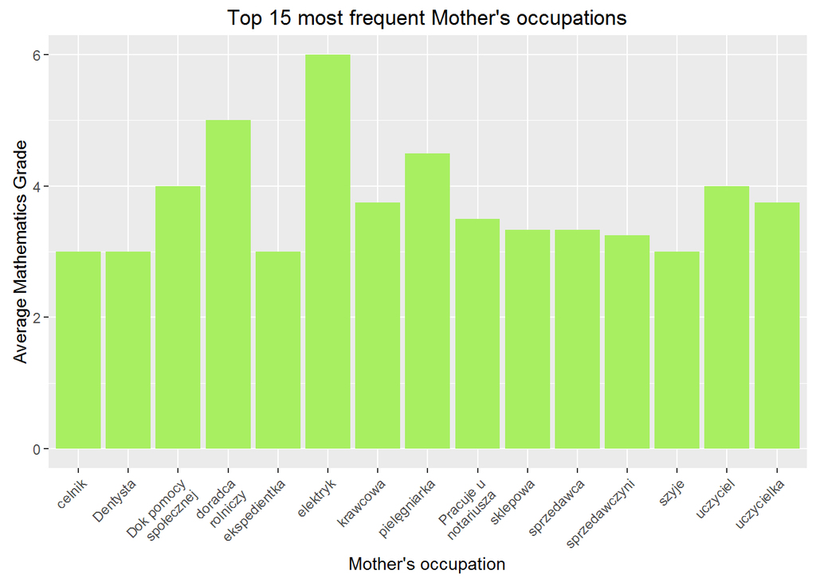

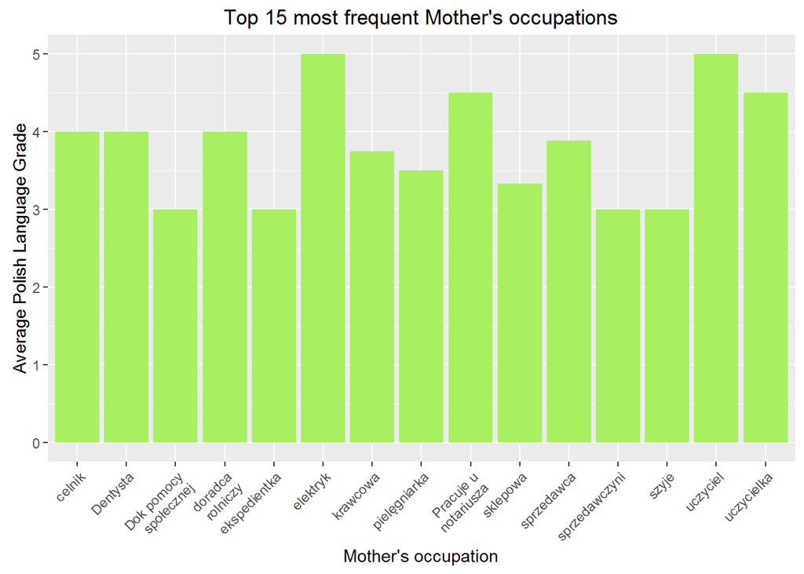

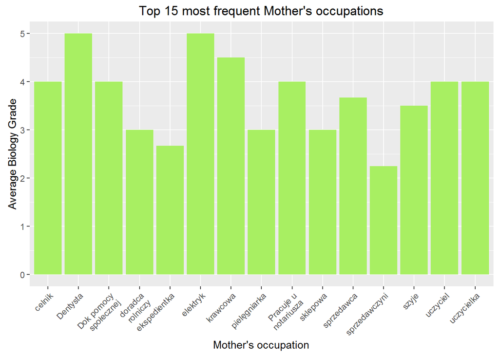

### Father

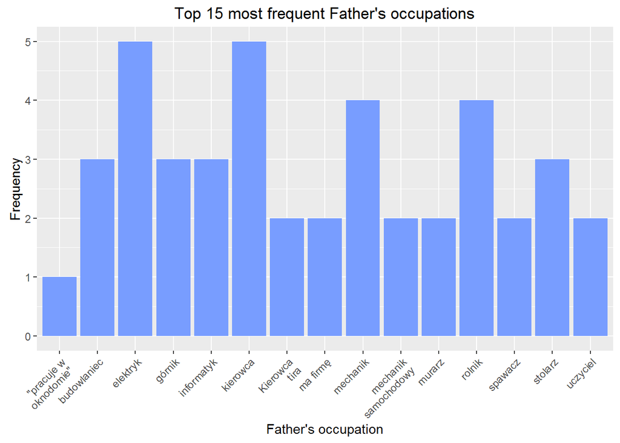

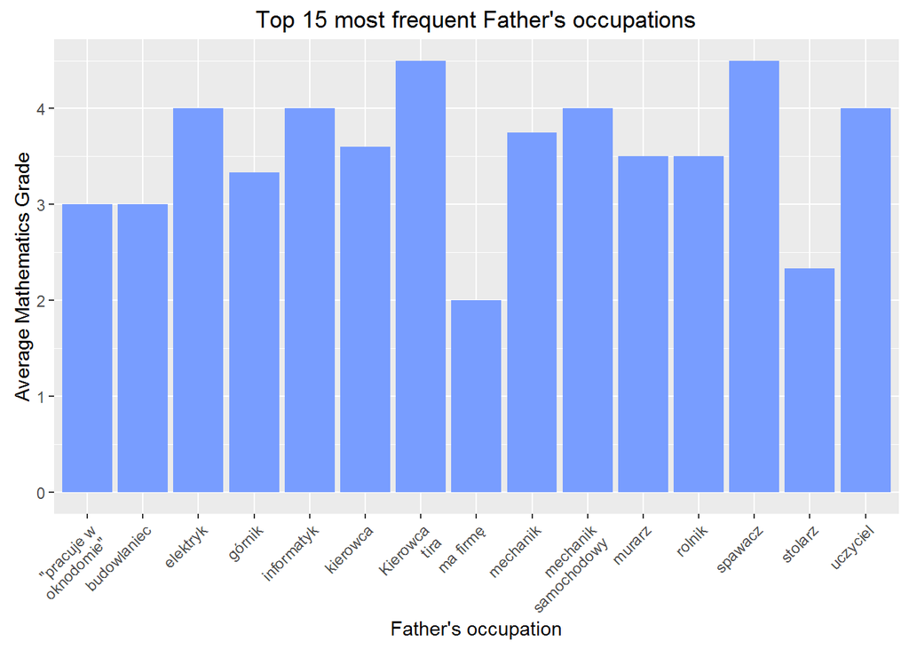

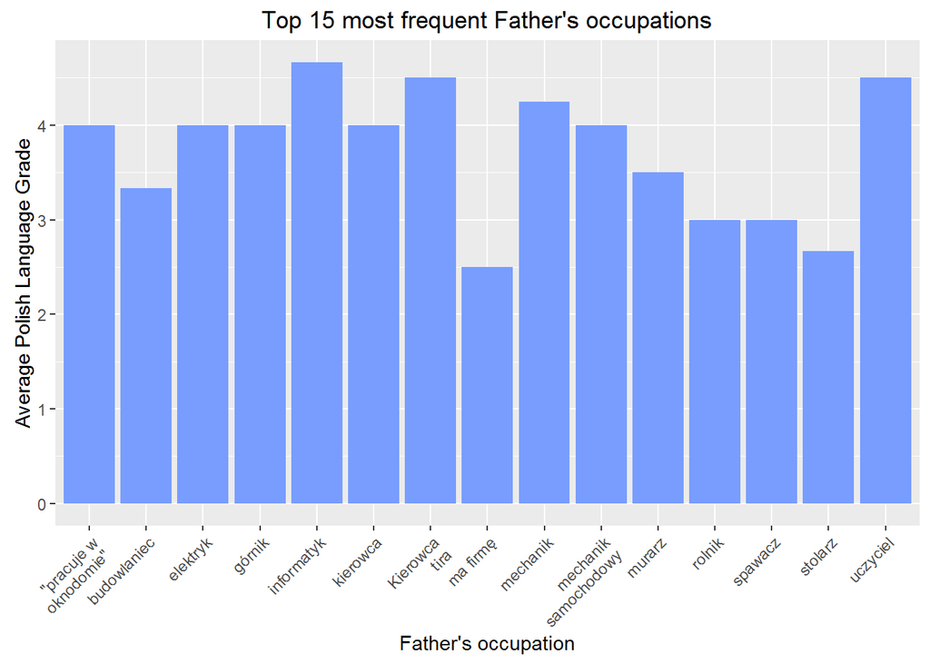

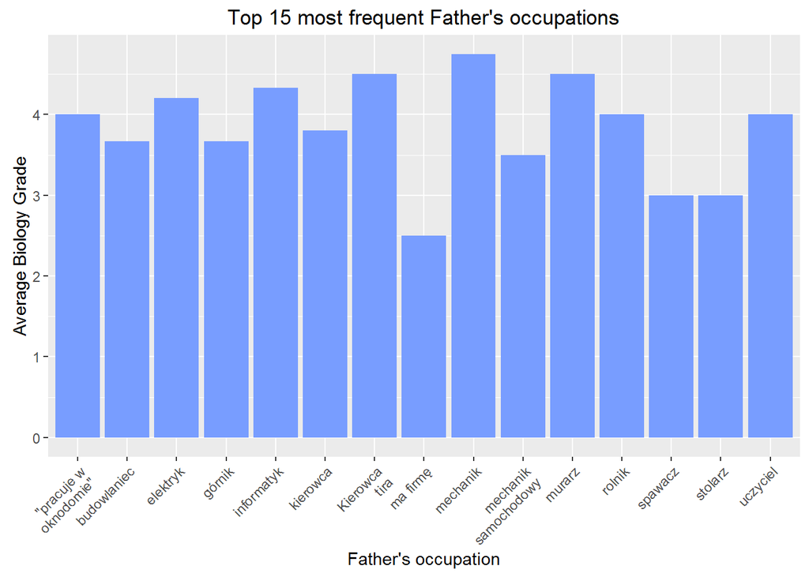

The most frequent fathers jobs are electrician and driver. Among the occupations where the highest average child’s grade can be observed are: driver, computer scientist, teacher, mechanic. Surprisingly children with lowest grades have fathers owning a company.

The reason may be that such parents do not have enough time to help the child with school.

## Studies status

Studies status describes whether a parent has obtained a higher education.

### Mother

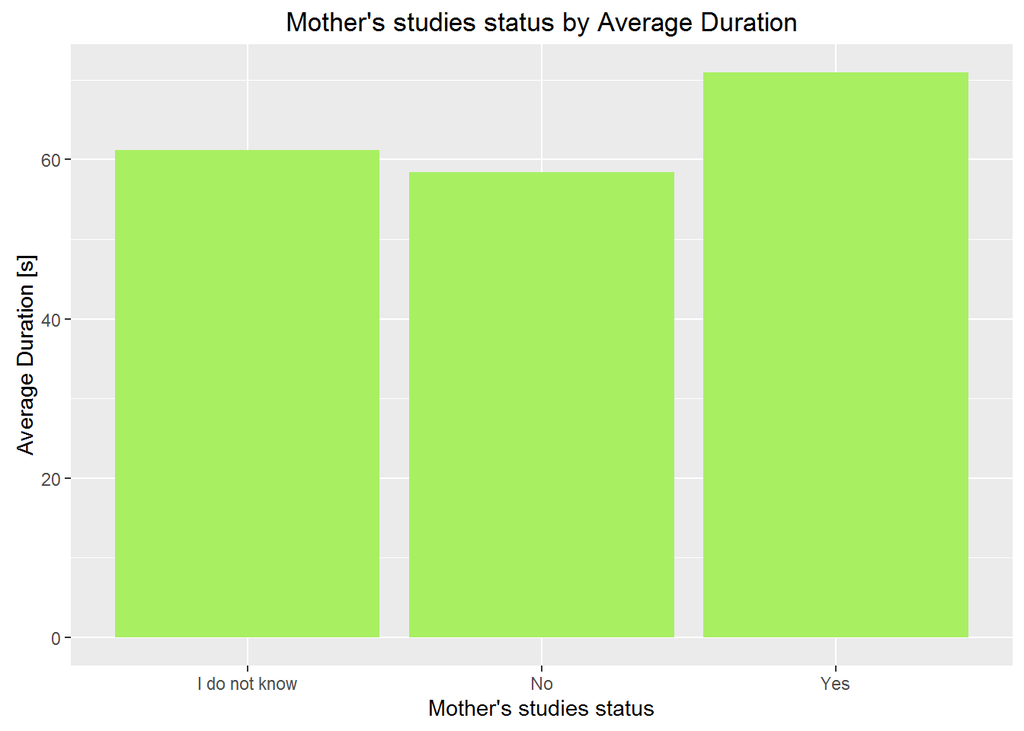

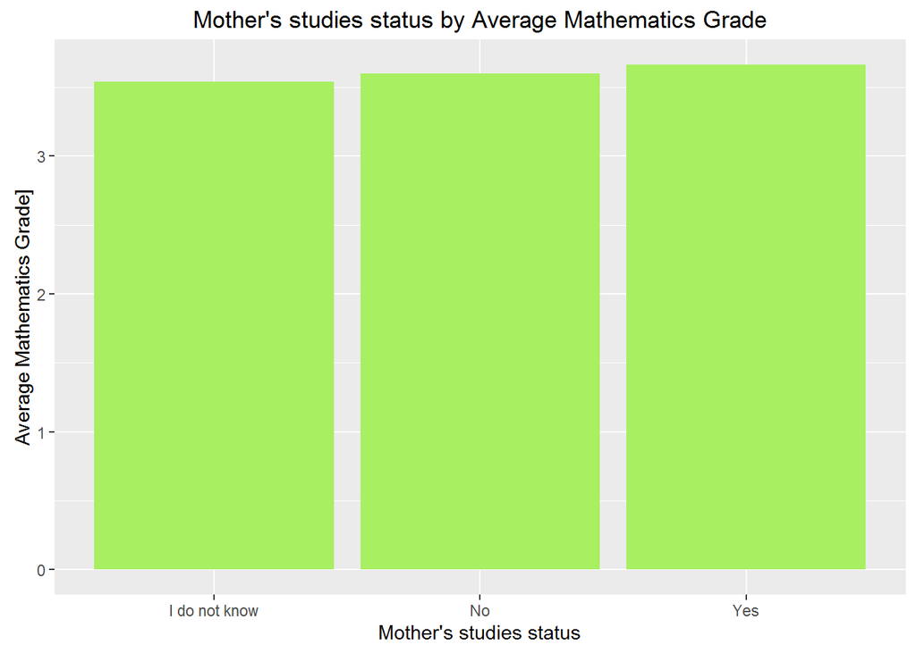

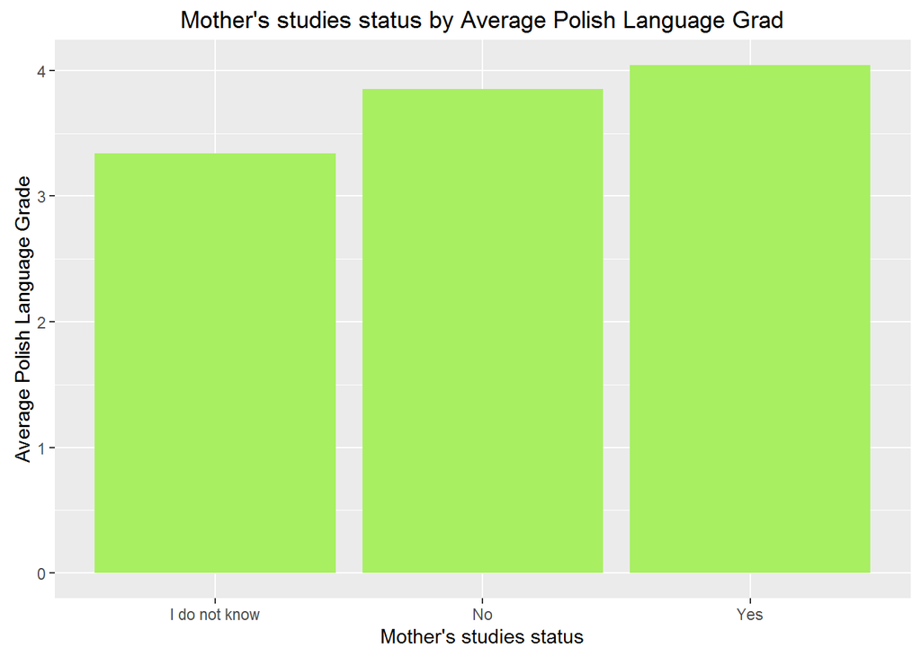

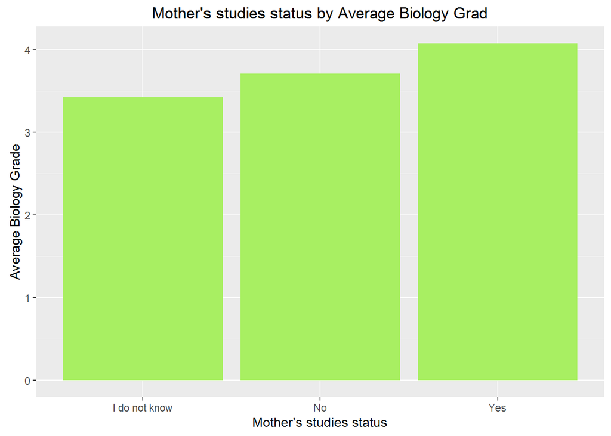

It is clear that students whose mothers studied have higher average grades and also spend on average 10 seconds more interacting with a unit.

### Father

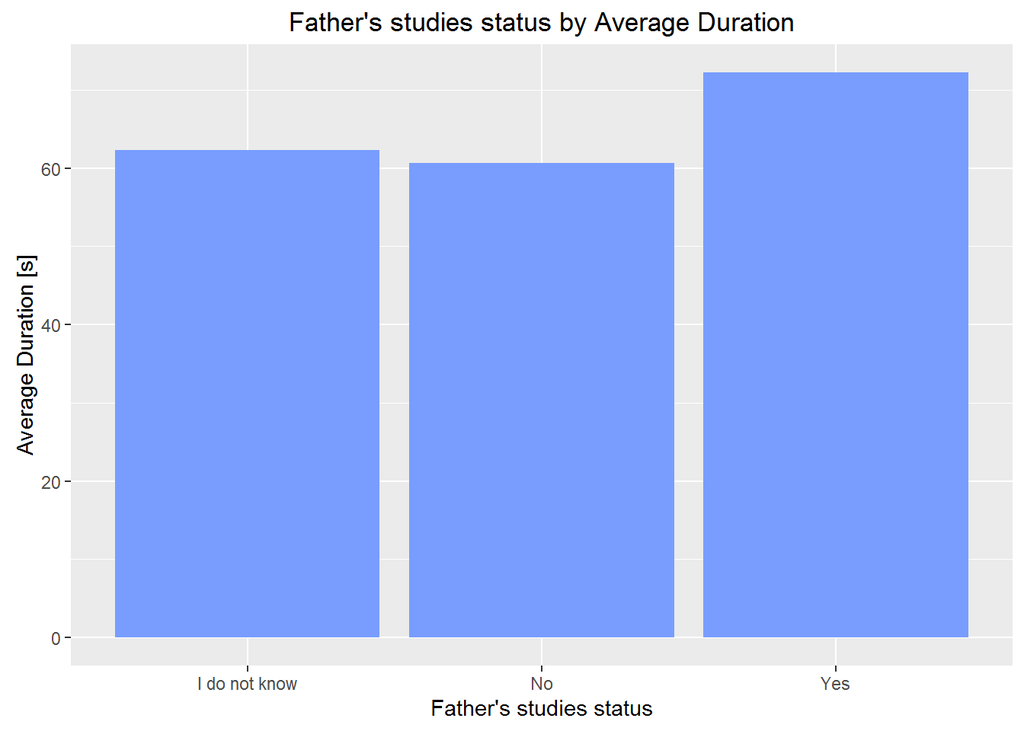

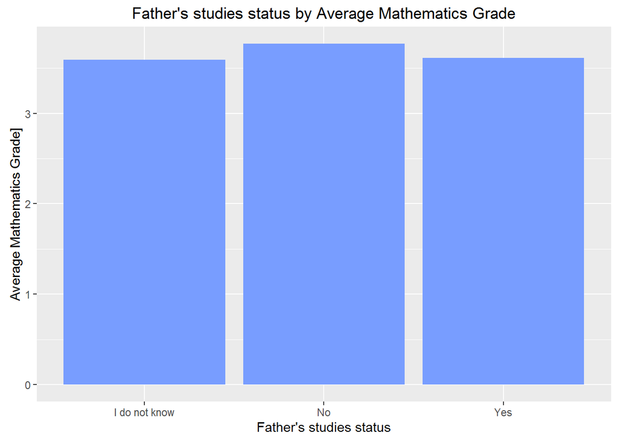

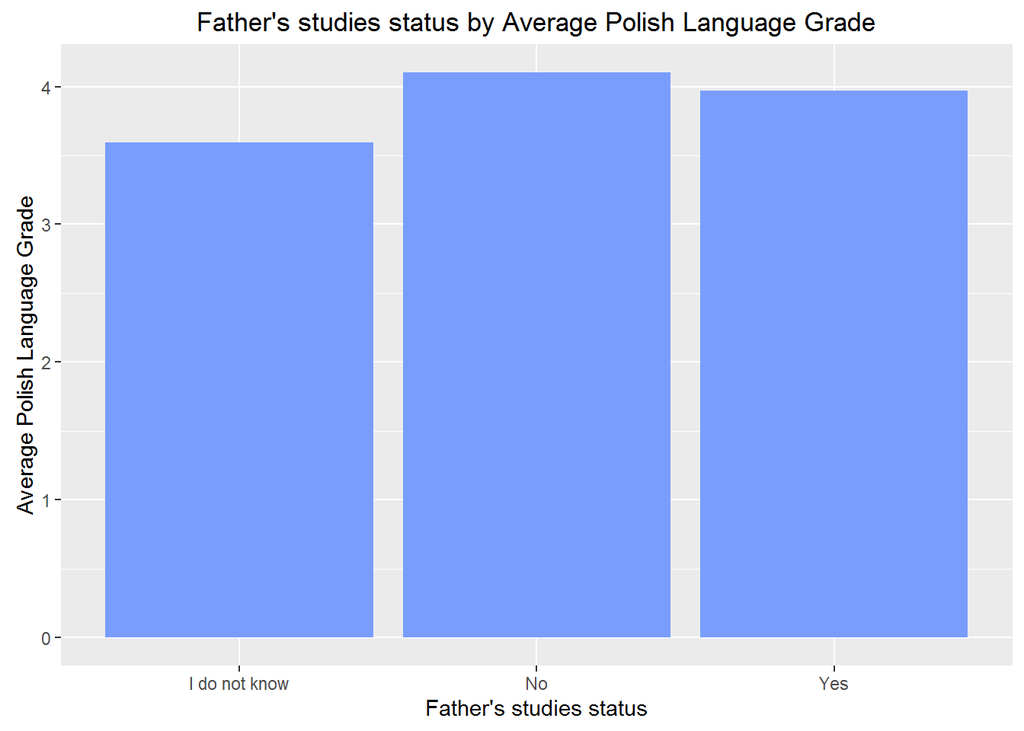

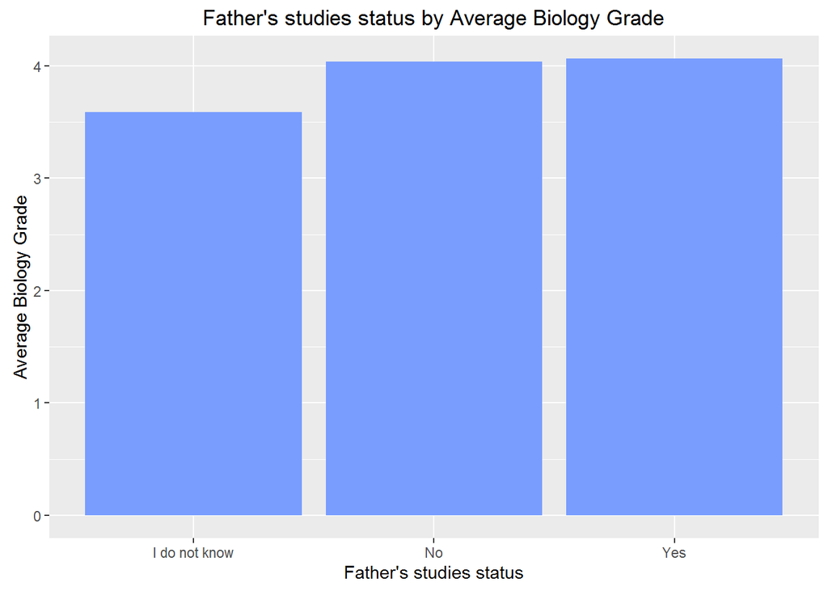

In case of fathers there is no significant difference in the average grade of their child for both Yes and No answers, but students that do not know about their parents study status have on average lower grades.

# School Analysis

In this section different schools are the subject of analysis.

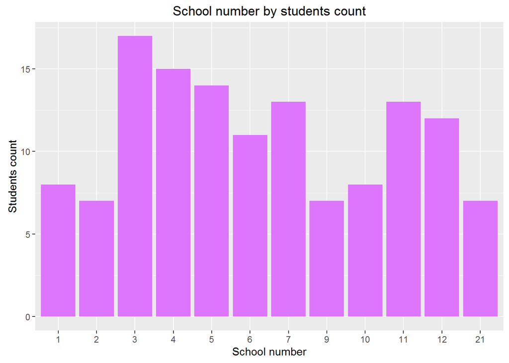

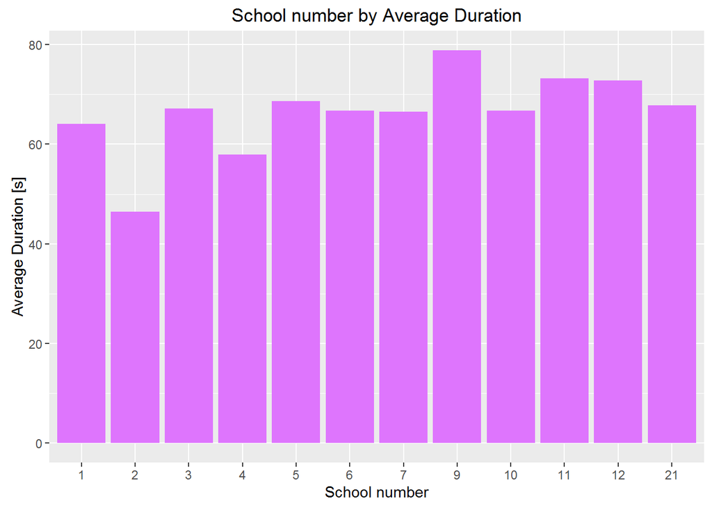

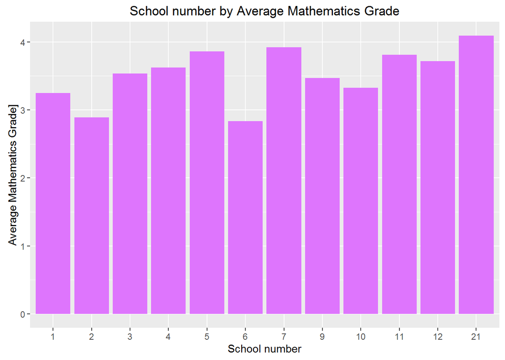

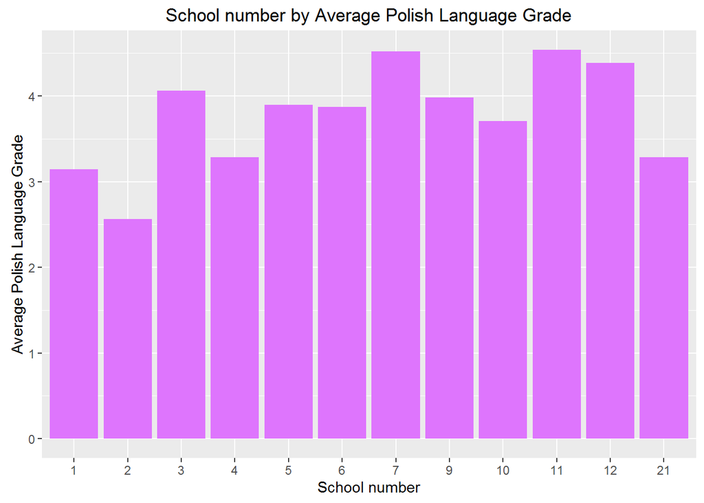

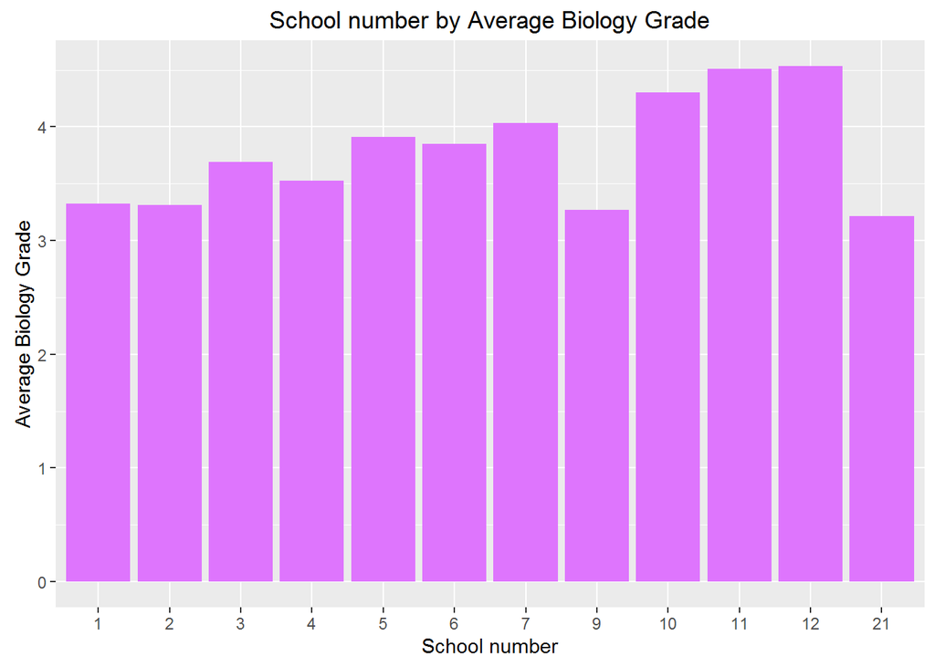

# Conclusions